# R Notebook

Bereits in anderen scripten wurde vorbereitet:

- Fußwegen von einer großen Sichprobe von (*Wohn*-)Gebäuden zu allen Schulen wurden berechnet und in `route_matrix.csv` gespeichert
- Die Stichprobe wurde in `sampled_buildings.csv` gespeichert

Die Daten werden wiefolgt vorbereitet:

- pro Block werden die Anzahl der einzuschulenden Kinder mit Hilfe der Einwohnerzahlen nach Alter auf LOR-Ebene in `EWR201512E_Matrix.csv` hochgerechnet
  - Kinder des LOR werden Anteilig nach Einwohnerzahl des Blocks im Verhältnis zum LOR auf die Blöcke verteilt
- es werden minimale, durchschnittliche und maximale Fußwege aus jedem Block errechnet

TODO: - die sozioökonomischen Faktoren werden aus den Wahlbezirken auf die Blöcke hochgerechnet (https://github.com/berlinermorgenpost/cogran)

## Laden der Daten

```r
sampled_buildings = read_rds('output/sampled_buildings.rds')
bez = readOGR('download/RBS_OD_BEZ_2015_12.geojson', layer = 'OGRGeoJSON', stringsAsFactors = FALSE)
blk = readOGR('download/RBS_OD_BLK_2015_12.geojson', layer = 'OGRGeoJSON', stringsAsFactors = FALSE)
lor = readOGR('download/RBS_OD_LOR_2015_12.geojson', layer = 'OGRGeoJSON', stringsAsFactors = FALSE)
re_schulstand = readOGR('download/re_schulstand.geojson', layer = 'OGRGeoJSON', stringsAsFactors = FALSE)
```

### Schulwege

```r
route_matrix = read_rds('output/route_matrix.rds')
```

### Schulkapazitäten und Einwohnerzahler auf LOR-Ebene

```r
kapas = read_csv('download/anmeldezahlen.csv') %>% filter(grepl('G', Schulnummer)) %>% filter(!is.na(`Plätze`))
einwohner_lor = read_delim('download/EWR201512E_Matrix.csv', delim=';')
```

## Überprüfung der Vollständigkeit der Daten über Anmeldezahlen/Kapazitäten

```r
re_schulstand_df = re_schulstand %>% as.data.frame() %>% rename(lon=coords.x1, lat=coords.x2)
re_schulstand_df %>% filter(grepl('G', spatial_name)) %>% mutate(BEZIRK=enc2utf8(as.character(BEZIRK))) %>%
  group_by(BEZIRK) %>% summarise(`Anzahl Schulen` = n()) %>%
  rename(Bezirk=BEZIRK) %>% left_join(kapas %>% group_by(Bezirk) %>% summarise(`Mit Kapazität` = n()))
```

| Bezirk | Anzahl Schulen | Mit Kapazität |
| --- | --- | --- |
| Charlottenburg-Wilmersdorf | 24 | 27 |
| Friedrichshain-Kreuzberg | 30 | NA |
| Lichtenberg | 25 | 25 |
| Marzahn-Hellersdorf | 26 | 29 |
| Mitte | 32 | 32 |
| Neukölln | 36 | 34 |
| Pankow | 42 | 42 |
| Reinickendorf | 31 | 30 |
| Spandau | 29 | 29 |
| Steglitz-Zehlendorf | 31 | 31 |

[output cut: 2 more lines]

Für welche Bezirke haben wir für alle Schulen Kapazitäten gegeben?

```r
re_schulstand %>% as.data.frame() %>% filter(grepl('G', spatial_name)) %>% mutate(BEZIRK=enc2utf8(as.character(BEZIRK))) %>% group_by(BEZIRK) %>% summarise(`Anzahl Schulen` = n()) %>%
  rename(Bezirk=BEZIRK) %>% left_join(kapas %>% group_by(Bezirk) %>% summarise(`Mit Kapazität` = n())) %>% filter(`Anzahl Schulen` == `Mit Kapazität`)
```

| Bezirk | Anzahl Schulen | Mit Kapazität |
| --- | --- | --- |
| Lichtenberg | 25 | 25 |
| Mitte | 32 | 32 |
| Pankow | 42 | 42 |
| Spandau | 29 | 29 |
| Steglitz-Zehlendorf | 31 | 31 |
| Tempelhof-Schöneberg | 32 | 32 |

Überprüfung ob die Liste der Schulen und Liste der Schulen mit Kapazitätsinformationen gleich sind:

```r
bezirk = 'Tempelhof-Schöneberg'
schulen_mit_kapa = kapas %>% filter(Bezirk == bezirk) %>% .$Schulnummer
schulen_mit_kapa
```

```
 [1] "07G01" "07G02" "07G03" "07G05" "07G06" "07G07" "07G10" "07G12" "07G13" "07G14" "07G15"
[12] "07G16" "07G17" "07G18" "07G19" "07G20" "07G21" "07G22" "07G23" "07G24" "07G25" "07G26"
[23] "07G27" "07G28" "07G29" "07G30" "07G31" "07G32" "07G34" "07G35" "07G36" "07G37"
```

```r
grundschulen = re_schulstand %>% as.data.frame() %>% filter(grepl('G', spatial_name)) %>% filter(BEZIRK == bezirk) %>% .$spatial_name
'In Anmeldeliste, fehlt in Schulstand'
```

```
[1] "In Anmeldeliste, fehlt in Schulstand"
```

```r
setdiff(schulen_mit_kapa, grundschulen)
```

```
character(0)
```

```r
'In re_schulstand, fehlt in Anmeldeliste'
```

```
[1] "In re_schulstand, fehlt in Anmeldeliste"
```

```r
setdiff(grundschulen, schulen_mit_kapa)
```

```
character(0)
```

```r
map = get_map('Berlin')
```

```r
re_schulstand_df_w_kapas = re_schulstand_df %>% left_join(kapas, by=c('spatial_name'='Schulnummer'))
```

Plot aller Schulen, mit der Info, ob Kapazitätsinformationen verfügbar sind.

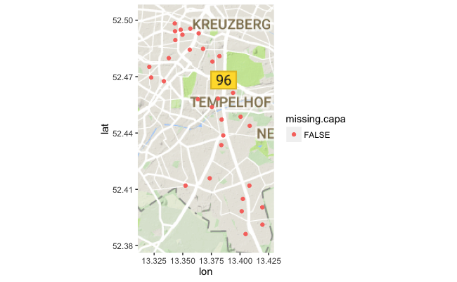

```r
data = re_schulstand_df_w_kapas %>% filter(grepl('G', spatial_name)) %>% filter(BEZIRK==bezirk) %>% mutate(missing.capa=is.na(`Plätze`))
ggmap(map) + geom_point(aes(lon, lat, color=missing.capa), data=data) +
    coord_map(xlim=c(min(data$lon)-0.01, max(data$lon)+0.01), ylim=c(min(data$lat)-0.01, max(data$lat)+0.01))
```

Filter auf Schulen mit Kapazitätsinformationen (für T-S sind das alle):

```r
relevant_schools = re_schulstand_df_w_kapas %>% filter(grepl('G', spatial_name)) %>% filter(BEZIRK==bezirk & !is.na(`Plätze`)) %>% .$spatial_name
relevant_schools
```

```
 [1] "07G01" "07G02" "07G03" "07G05" "07G06" "07G07" "07G10" "07G12" "07G13" "07G14" "07G15"
[12] "07G16" "07G17" "07G18" "07G19" "07G20" "07G21" "07G22" "07G23" "07G24" "07G25" "07G26"
[23] "07G27" "07G28" "07G29" "07G30" "07G31" "07G32" "07G34" "07G35" "07G36" "07G37"
```

## Mapping Bezirk->LOR->Block

```r
df_bez = as.data.frame(bez)
df_lor = as.data.frame(lor)
df_blk = as.data.frame(blk)
```

### Sanity-Check: LORs und Blöcke im Bezirk

```r
bez_id = filter(df_bez, BEZNAME == bezirk)$BEZ
relevant_lors = df_lor %>% filter(BEZ == bez_id)
relevant_blks = df_blk %>% filter(BEZ == bez_id)
```

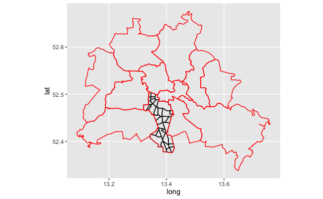

```r
ggplot() + geom_path(aes(x=long, y=lat, group=group), data=lor[lor$BEZ == bez_id,]) + coord_map() + geom_path(aes(x=long, y=lat, group=group), data=bez, color='red')
```

### Blöcke im Bezirk

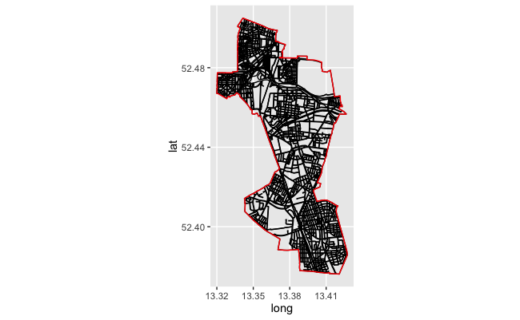

```r
ggplot() + geom_path(aes(x=long, y=lat, group=group), data=blk[blk$BEZ == bez_id,]) + coord_map() + geom_path(aes(x=long, y=lat, group=group), data=bez[bez$BEZ == bez_id,], color='red')
```

## Kinder im Bezirk auf Blöcke hochrechnen

Über die Einwohnerinformationen in `RBS_OD_BLK_2015_12.geojson` kann `EWR201512E_Matrix.csv` von LOR-Ebene auf Blockebene hochgerechnet werden.

TODO: Stattdessen mit https://github.com/berlinermorgenpost/cogran machen?

### Plot der 6-Jährigen nach `EWR201512E_Matrix.csv`

TODO neue Daten von Torres? TODO Mittel über mehrere Jahre verwenden? Prognose?

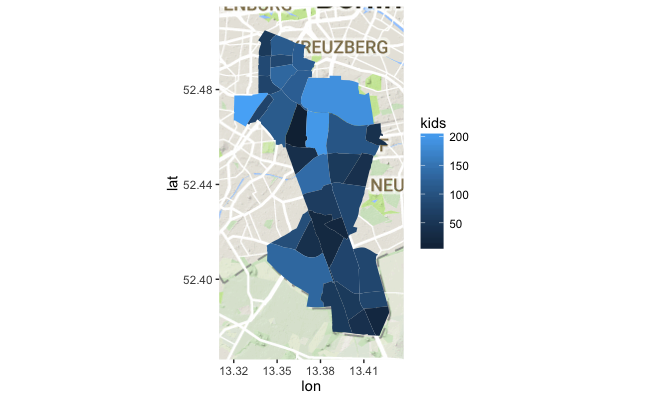

```r
relevant_ewr = einwohner_lor %>% select(RAUMID, E_E06_07) %>% filter(RAUMID %in% relevant_lors$PLR) %>%
  mutate(kids=as.numeric(gsub(',','.',E_E06_07))) %>% as.data.frame()
data = tidy(lor[lor$BEZ == bez_id,], region='PLR') %>% inner_join(relevant_ewr, by=c('id'='RAUMID'))
ggmap(map) + geom_polygon(aes(x=long, y=lat, group=group, fill=kids), data=data) +
  coord_map(xlim=c(min(data$long)-0.01, max(data$long)+0.01), ylim=c(min(data$lat)-0.01, max(data$lat)+0.01))
```

### Plot der Einwohner auf Blockebene

```r
data = tidy(blk[blk$BEZ == bez_id,], region='BLK') %>% inner_join(df_blk, by=c('id'='BLK')) %>% mutate(Einw=ifelse(Einw==0, NA, Einw))
0
```

```
[1] 0
```

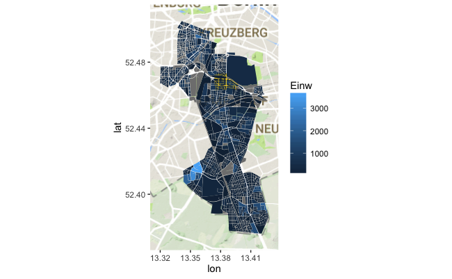

```r
ggmap(map) + geom_polygon(aes(x=long, y=lat, group=group, fill=Einw), data=data) +
  coord_map(xlim=c(min(data$long)-0.01, max(data$long)+0.01), ylim=c(min(data$lat)-0.01, max(data$lat)+0.01))
```

### Hochrrechnung auf Blöcke

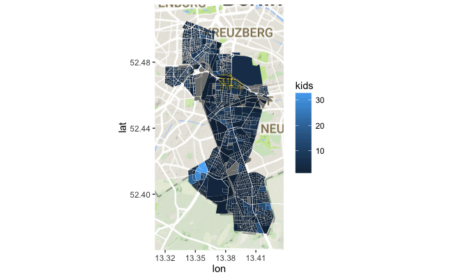

```r
kids_in_blks = relevant_blks %>% group_by(PLR) %>% mutate(EinwRatio = Einw/sum(Einw)) %>% ungroup %>% left_join(relevant_ewr, by=c('PLR'='RAUMID')) %>% mutate(kids = EinwRatio*kids) %>% select(BEZ, PLR, BLK, Einw, kids) %>% as.data.frame()
row.names(kids_in_blks) = kids_in_blks$BLK
data = tidy(blk[blk$BEZ == bez_id,], region='BLK') %>% inner_join(kids_in_blks, by=c('id'='BLK')) %>% mutate(kids=ifelse(kids==0, NA, kids), Einw=ifelse(Einw==0, NA, Einw))
ggmap(map) + geom_polygon(aes(x=long, y=lat, group=group, fill=kids), data=data) +
  coord_map(xlim=c(min(data$long)-0.01, max(data$long)+0.01), ylim=c(min(data$lat)-0.01, max(data$lat)+0.01))
```

## Verfügbare Plätze

```r
relevant_kapas = kapas %>% select(Schulnummer, Kapa=`Plätze`) %>% filter(Schulnummer %in% relevant_schools) %>% as.data.frame()
#row.names(relevant_kapas) = relevant_kapas$Schulnummer
```

### Überprüfung der Summe der Kapazitäten, Anmeldungen und Kinderstatistiken

```r
'Summe Kapas'
```

```
[1] "Summe Kapas"
```

```r
relevant_kapas %>% .$Kapa %>% sum
```

```
[1] 2584
```

```r
'Anmeldungen'
```

```
[1] "Anmeldungen"
```

```r
kapas %>% mutate(Anmeldungen = as.numeric(gsub('[^0-9]', '', Anmeldungen))) %>% filter(Schulnummer %in% relevant_schools) %>% .$Anmeldungen %>% sum
```

```
[1] 2752
```

```r
'Kids laut Statistik'
```

```
[1] "Kids laut Statistik"
```

```r
kids_in_blks$kids %>% sum
```

```
[1] 2855
```

```r
relevant_ewr$kids %>% sum
```

```
[1] 2855
```

## Schulwege von Blöcken zu Schulen aggregieren

Für jedes Wohngebäude suchen wir den zugehörigen Block

```r
residential_buildings_blocks = sampled_buildings %>% inner_join(df_blk) %>% filter(BEZ == bez_id)
residential_buildings_blocks
```

| OI | long | lat | BLK | BEZ | PLR | Einw |
| --- | --- | --- | --- | --- | --- | --- |
| DEBE000000123825 | 13.35884 | 52.49425 | 054082 | 07 | 07010103 | 339 |
| DEBE000000128640 | 13.36118 | 52.49207 | 054083 | 07 | 07010104 | 789 |
| DEBE000000158226 | 13.36227 | 52.49357 | 054083 | 07 | 07010104 | 789 |
| DEBE000000178849 | 13.36176 | 52.49049 | 054105 | 07 | 07010104 | 127 |
| DEBE000000178851 | 13.36153 | 52.49047 | 054105 | 07 | 07010104 | 127 |
| DEBE000000062469 | 13.36380 | 52.49127 | 054106 | 07 | 07010104 | 428 |
| DEBE000000116479 | 13.36260 | 52.49110 | 054106 | 07 | 07010104 | 428 |
| DEBE000000116367 | 13.36484 | 52.49121 | 054107 | 07 | 07010104 | 61 |
| DEBE000000063525 | 13.33747 | 52.48812 | 054119 | 07 | 07020201 | 323 |
| DEBE000000024940 | 13.33794 | 52.48781 | 054119 | 07 | 07020201 | 323 |

[output cut: 990 more lines]

```r
routes_from_blks = residential_buildings_blocks %>%
  left_join(route_matrix %>% filter(dst %in% relevant_schools), by=c('OI'='src'))
head(routes_from_blks)
```

| OI | long | lat | BLK | BEZ | PLR | Einw | dst | duration | distance |
| --- | --- | --- | --- | --- | --- | --- | --- | --- | --- |
| DEBE000000123825 | 13.35884 | 52.49425 | 054082 | 07 | 07010103 | 339 | 07G01 | 3.5 | 289.1610 |
| DEBE000000123825 | 13.35884 | 52.49425 | 054082 | 07 | 07010103 | 339 | 07G02 | 19.2 | 1580.1466 |
| DEBE000000123825 | 13.35884 | 52.49425 | 054082 | 07 | 07010103 | 339 | 07G03 | 10.1 | 833.1254 |
| DEBE000000123825 | 13.35884 | 52.49425 | 054082 | 07 | 07010103 | 339 | 07G05 | 18.4 | 1522.3086 |
| DEBE000000123825 | 13.35884 | 52.49425 | 054082 | 07 | 07010103 | 339 | 07G06 | 32.9 | 2736.7563 |
| DEBE000000123825 | 13.35884 | 52.49425 | 054082 | 07 | 07010103 | 339 | 07G07 | 62.4 | 5166.5781 |

### Plot der relevanten Blöcke (mit Wohngebäuden)

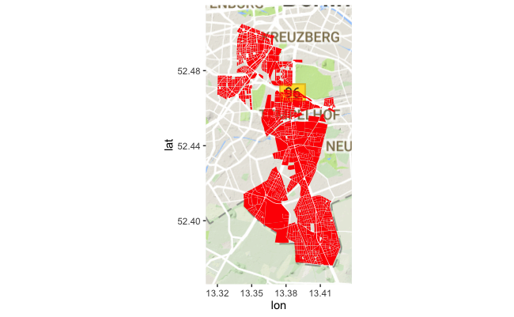

```r
data = tidy(blk[blk$BEZ == bez_id,], region='BLK') %>% inner_join(routes_from_blks %>% group_by(BLK) %>% summarise(n=n()), by=c('id'='BLK'))
ggmap(map) + geom_polygon(aes(x=long, y=lat, group=group), fill='red', data=data) +
  #geom_point(aes(x=lon, y=lat), data=rb_df, color='black', size=0.01) +
  coord_map(xlim=c(min(data$long)-0.01, max(data$long)+0.01), ylim=c(min(data$lat)-0.01, max(data$lat)+0.01))
```

```r
travel_from_blks = routes_from_blks %>% as.data.frame() %>% group_by(BLK, dst) %>% summarise(min=min(distance), avg=mean(distance), med=median(distance), max=max(distance)) %>% ungroup
travel_from_blks
```

| BLK | dst | min | avg | med | max |
| --- | --- | --- | --- | --- | --- |
| 054082 | 07G01 | 289.16101 | 289.1610 | 289.1610 | 289.1610 |
| 054082 | 07G02 | 1580.14661 | 1580.1466 | 1580.1466 | 1580.1466 |
| 054082 | 07G03 | 833.12537 | 833.1254 | 833.1254 | 833.1254 |
| 054082 | 07G05 | 1522.30859 | 1522.3086 | 1522.3086 | 1522.3086 |
| 054082 | 07G06 | 2736.75635 | 2736.7563 | 2736.7563 | 2736.7563 |
| 054082 | 07G07 | 5166.57812 | 5166.5781 | 5166.5781 | 5166.5781 |
| 054082 | 07G10 | 1428.14233 | 1428.1423 | 1428.1423 | 1428.1423 |
| 054082 | 07G12 | 1067.17163 | 1067.1716 | 1067.1716 | 1067.1716 |
| 054082 | 07G13 | 366.32883 | 366.3288 | 366.3288 | 366.3288 |
| 054082 | 07G14 | 1482.17615 | 1482.1761 | 1482.1761 | 1482.1761 |

[output cut: 990 more lines]

### Plot der Blöcke mit Färbung nach durchschnittlichem Weg zur nächsten Schule

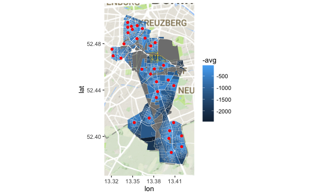

```r
data = tidy(blk[blk$BEZ == bez_id,], region='BLK') %>% left_join(travel_from_blks %>% group_by(BLK) %>% top_n(1, -avg), by=c('id'='BLK'))
ggmap(map) + geom_polygon(aes(x=long, y=lat, group=group, fill=-avg), data=data) +
  geom_point(aes(lon, lat), color='red', data = re_schulstand_df %>% filter(BEZIRK==bezirk & SCHULART=='Grundschule')) +
  coord_map(xlim=c(min(data$long)-0.01, max(data$long)+0.01), ylim=c(min(data$lat)-0.01, max(data$lat)+0.01))
```

```r
travel_matrix = travel_from_blks %>% select(BLK, dst, avg) %>% spread(dst, avg)
dim(travel_matrix)
```

```
[1] 1012   33
```

```r
travel_matrix
```

|  | BLK | 07G01 | 07G02 | 07G03 | 07G05 | 07G06 | 07G07 | 07G10 | 07G12 | 07G13 | 07G14 | 07G15 | 07G16 | 07G17 | 07G18 | 07G19 | 07G20 | 07G21 | 07G22 | 07G23 | 07G24 | 07G25 | 07G26 | 07G27 | 07G28 | 07G29 | 07G30 | 07G31 | 07G32 | … |
| --- | --- | --- | --- | --- | --- | --- | --- | --- | --- | --- | --- | --- | --- | --- | --- | --- | --- | --- | --- | --- | --- | --- | --- | --- | --- | --- | --- | --- | --- | --- |
| 1 | 054082 | 289.1610 | 1580.1466 | 833.12537 | 1522.3086 | 2736.7563 | 5166.5781 | 1428.1423 | 1067.1716 | 366.3288 | 1482.1761 | 3755.4231 | 4201.6973 | 4431.04102 | 886.79352 | 5207.7163 | 5082.6768 | 2778.6562 | 5469.2900 | 6856.8647 | 2845.7930 | 6510.35303 | 12590.3779 | 7475.2725 | 9915.2910 | 13488.91504 | 12130.18848 | 7846.7134 | 11409.62988 | … |
| 2 | 054083 | 642.5668 | 1937.5903 | 1186.53113 | 1246.3454 | 2490.3268 | 4890.6152 | 1160.9110 | 1410.6432 | 313.9740 | 1493.3678 | 3488.1919 | 3955.2678 | 4163.80981 | 1048.22272 | 4893.1482 | 4768.1084 | 2530.4749 | 5154.7219 | 6542.2964 | 2531.2247 | 6195.78467 | 12275.8091 | 7160.7041 | 9600.7227 | 13174.34619 | 11815.61963 | 7532.1450 | 11095.06103 | … |
| 3 | 054105 | 977.1123 | 2070.8618 | 1503.44153 | 963.9644 | 2291.2799 | 4608.2341 | 943.5716 | 1529.9427 | 565.8045 | 1299.0300 | 3270.8525 | 3756.2209 | 3958.51685 | 1020.47827 | 4649.3721 | 4524.3323 | 2320.5923 | 4910.9460 | 6298.5205 | 2287.4490 | 5952.00879 | 12032.0332 | 6916.9285 | 9356.9468 | 12930.57031 | 11571.84375 | 7288.3691 | 10851.28516 | … |
| 4 | 054106 | 911.5521 | 2202.5377 | 1455.51642 | 1096.4819 | 2448.9011 | 4738.3303 | 1110.3391 | 1690.6796 | 415.7256 | 1454.1837 | 3437.6200 | 3913.8420 | 4119.26099 | 1146.21655 | 4702.5430 | 4577.5029 | 2356.4633 | 4964.1167 | 6351.6912 | 2340.6195 | 6005.17944 | 12085.2041 | 6970.0989 | 9410.1172 | 12983.74121 | 11625.01465 | 7341.5398 | 10904.45605 | … |
| 5 | 054107 | 1021.3695 | 2312.3550 | 1565.33386 | 1014.0298 | 2546.4871 | 4658.2998 | 1113.7411 | 1785.1499 | 365.8797 | 1554.2371 | 3485.5249 | 3972.7866 | 4173.18897 | 1265.50513 | 4607.8535 | 4482.8135 | 2261.7739 | 4869.4272 | 6257.0020 | 2245.9302 | 5910.49023 | 11990.5146 | 6875.4097 | 9315.4277 | 12889.05176 | 11530.32519 | 7246.8506 | 10809.76660 | … |
| 6 | 054119 | 1878.5908 | 1415.4501 | 1322.63440 | 2426.9966 | 994.6596 | 4830.9900 | 1668.1595 | 1020.0360 | 2171.7223 | 513.3576 | 2548.9470 | 2341.2889 | 2690.40247 | 1133.62842 | 5362.8953 | 4937.1008 | 3839.8262 | 5323.7141 | 6834.6536 | 3707.1863 | 6443.77466 | 12523.7993 | 7329.6965 | 9757.2676 | 13422.33643 | 12031.04053 | 7824.5022 | 11343.05127 | … |
| 7 | 054120 | 1922.0093 | 1459.0558 | 1366.79236 | 2380.8669 | 901.2454 | 4718.6650 | 1576.8690 | 1064.1939 | 2215.1409 | 556.7761 | 2455.5327 | 2319.2637 | 2668.37720 | 1177.04688 | 5271.6050 | 4845.8101 | 3793.6963 | 5232.4236 | 6743.3630 | 3615.8959 | 6352.48413 | 12432.5083 | 7238.4060 | 9639.7158 | 13331.04541 | 11939.74951 | 7733.2117 | 11251.76025 | … |
| 8 | 054121 | 1834.8431 | 1416.4692 | 1274.93213 | 2216.5278 | 1000.3014 | 4558.5188 | 1412.5297 | 972.3337 | 2127.9746 | 469.6099 | 2447.6688 | 2443.5691 | 2792.68262 | 1089.88074 | 5107.2654 | 4681.4709 | 3629.3573 | 5068.0845 | 6579.0239 | 3451.5565 | 6188.14502 | 12268.1694 | 7074.0669 | 9479.5698 | 13166.70654 | 11775.41064 | 7568.8726 | 11087.42139 | … |
| 9 | 054122 | 1720.4228 | 1352.7516 | 1168.32416 | 2074.8444 | 1141.8256 | 4477.4258 | 1293.5609 | 905.2991 | 2013.5543 | 357.4295 | 2544.1011 | 2590.0952 | 2939.20874 | 975.63593 | 4988.2966 | 4562.5020 | 3487.6738 | 4949.1155 | 6460.0549 | 3332.5878 | 6069.17603 | 12149.2007 | 6955.0979 | 9395.1167 | 13047.73779 | 11656.44189 | 7449.9036 | 10968.45264 | … |
| 10 | 054123 | 1681.2854 | 1288.8871 | 1126.94678 | 2072.6320 | 1202.5186 | 4565.0938 | 1344.4156 | 843.0933 | 1974.4170 | 316.0522 | 2631.7688 | 2648.2872 | 2997.40088 | 936.32300 | 5075.9644 | 4650.1699 | 3485.4615 | 5036.7832 | 6547.7227 | 3375.4381 | 6156.84375 | 12236.8682 | 7042.7656 | 9482.7842 | 13135.40527 | 11744.10938 | 7537.5713 | 11056.12012 | … |

[output cut: 990 more lines]

# Select relevant data

```r
optim_kapas = relevant_kapas
optim_kids_in_blks = kids_in_blks %>% filter(kids > 0) %>% inner_join(travel_matrix, by='BLK') %>% select(BLK, kids) %>% mutate(kids=kids)
nrow(optim_kids_in_blks)
```

```
[1] 1012
```

```r
nrow(optim_kapas)
```

```
[1] 32
```

```r
select_schools = as.character(optim_kapas$Schulnummer)
select_blks = as.character(optim_kids_in_blks$BLK)
optim_matrix = inner_join(optim_kids_in_blks, travel_matrix, by='BLK')[select_schools]
dim(optim_matrix)
```

```
[1] 1012   32
```

```r
optim_kapas$Kapa %>% sum
```

```
[1] 2584
```

```r
optim_kids_in_blks$kids %>% sum
```

```
[1] 2844.886
```

## Naive Zuordnung: Jeder Block zur nächsten Schule

```r
solution = optim_matrix %>% mutate(BLK=optim_kids_in_blks$BLK) %>% gather(school, dist, -BLK) %>% group_by(BLK) %>% top_n(1, -dist) %>% ungroup
optim_matrix %>% t %>% as.data.frame %>% summarise_each(funs(min)) %>% sum()
```

```
[1] 776790.8
```

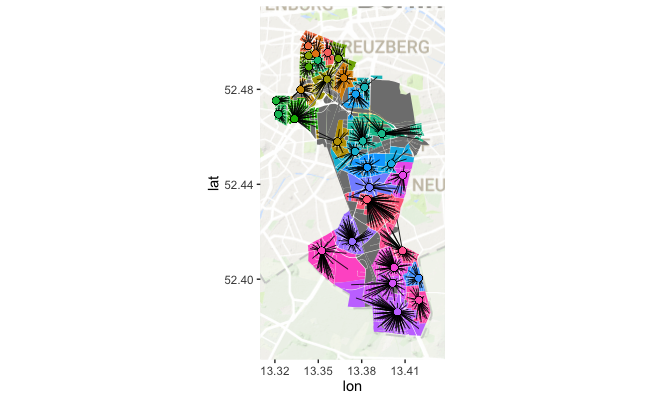

```r
solines = re_schulstand_df %>% inner_join(solution, by=c('spatial_name'='school')) %>% inner_join(cbind(as.data.frame(coordinates(blk[blk$BEZ == bez_id,])), blk[blk$BEZ == bez_id,]@data['BLK']))
data = tidy(blk[blk$BEZ == bez_id,], region='BLK') %>% left_join(solution, by=c('id'='BLK'))
ggmap(map, darken = c(0.5, 'white')) + geom_polygon(aes(x=long, y=lat, group=group, fill=school), data=data) +
  geom_segment(aes(x=V1,y=V2,xend=lon,yend=lat), data=solines, size=0.3) +
  geom_point(aes(lon, lat), color='black', size=2, data = re_schulstand_df %>% inner_join(solution, by=c('spatial_name'='school'))) +
  geom_point(aes(lon, lat, color=spatial_name), data = re_schulstand_df %>% inner_join(solution, by=c('spatial_name'='school'))) +
  coord_map(xlim=c(min(data$long)-0.01, max(data$long)+0.01), ylim=c(min(data$lat)-0.01, max(data$lat)+0.01)) +
  guides(color=F, fill=F)
```

## Darstellung der Zuordnung als Tabelle

```r
library(formattable)
```

```r
solution %>% inner_join(optim_kids_in_blks, by='BLK') %>% inner_join(travel_from_blks, by=c('BLK'='BLK', 'school'='dst')) %>%
  group_by(school) %>% summarise(
    kids=sum(kids),
    num_blocks=n(),
    min_dist=min(min),
    avg_dist=mean((kids*avg)/sum(kids)),
    max_dist=max(max)
  ) %>%
  inner_join(relevant_kapas, by=c('school'='Schulnummer')) %>%
  mutate(
    utilization=kids/Kapa
  ) %>% select(
   Schule=school,
   `Blöcke`=num_blocks,
   Kapazität=Kapa,
   Kinder=kids,
   Auslastung=utilization,
   `Weg (min)`=min_dist,
   `Weg (Ø)`=avg_dist,
   `Weg (max)`=max_dist
  ) %>%
  formattable(
    list(
      Kinder = formatter("span", x ~ digits(x, 2)),
      Auslastung = formatter("span",
        style = x ~ style(color = ifelse(x < 1, "green", "red")),
        x ~ icontext(ifelse(x < 1, "ok", "remove"), percent(x))
      ),
      `Weg (Ø)` = proportion_bar("lightblue"),
      `Weg (min)` = proportion_bar("lightblue"),
      `Weg (max)` = proportion_bar("lightblue")
    )
  )
```

| Schule | Blöcke | Kapazität | Kinder | Auslastung | Weg (min) | Weg (Ø) | Weg (max) |
| --- | --- | --- | --- | --- | --- | --- | --- |
| 07G01 | 12 | 66 | 51.71 | 78.34% | 289.050598 | 622.8855 | 1373.8352 |
| 07G02 | 19 | 98 | 46.59 | 47.54% | 51.055847 | 428.8580 | 882.5028 |
| 07G03 | 12 | 73 | 55.04 | 75.40% | 56.470993 | 446.4231 | 1130.7246 |
| 07G05 | 21 | 78 | 114.70 | 147.05% | 90.031578 | 564.3331 | 1028.1741 |
| 07G06 | 23 | 55 | 64.78 | 117.79% | 231.008301 | 767.9632 | 1348.4424 |
| 07G07 | 12 | 81 | 25.82 | 31.88% | 115.027184 | 682.9773 | 1434.8188 |
| 07G10 | 31 | 112 | 161.33 | 144.05% | 106.214981 | 652.7941 | 1247.4854 |
| 07G12 | 11 | 75 | 33.84 | 45.12% | 125.186012 | 353.8727 | 568.3472 |
| 07G13 | 26 | 82 | 135.72 | 165.51% | 57.502354 | 485.0052 | 981.8489 |
| 07G14 | 33 | 78 | 89.11 | 114.25% | 89.421890 | 442.4545 | 793.3059 |
| 07G15 | 55 | 104 | 235.00 | 225.96% | 171.173996 | 821.3397 | 1587.7103 |
| 07G16 | 18 | 104 | 48.30 | 46.44% | 219.531174 | 532.5962 | 989.6716 |
| 07G17 | 25 | 100 | 77.86 | 77.86% | 2.852539 | 416.8638 | 745.5230 |
| 07G18 | 22 | 44 | 75.38 | 171.33% | 80.083008 | 360.2015 | 664.1874 |
| 07G19 | 33 | 112 | 121.85 | 108.79% | 101.583176 | 1109.6033 | 2297.9089 |
| 07G20 | 47 | 81 | 177.89 | 219.62% | 29.751823 | 671.3297 | 1456.3486 |
| 07G21 | 22 | 72 | 78.64 | 109.22% | 75.870438 | 489.4627 | 1311.5264 |
| 07G22 | 26 | 91 | 70.47 | 77.43% | 75.211090 | 592.5649 | 1487.6127 |
| 07G23 | 10 | 50 | 25.83 | 51.66% | 85.342056 | 679.1631 | 1185.7365 |
| 07G24 | 27 | 75 | 83.84 | 111.78% | 115.889305 | 619.2938 | 1933.3115 |
| 07G25 | 36 | 75 | 146.10 | 194.80% | 44.704811 | 586.3832 | 1283.3223 |
| 07G26 | 23 | 52 | 31.10 | 59.80% | 79.045441 | 527.3240 | 1283.5569 |
| 07G27 | 20 | 75 | 61.11 | 81.48% | 144.707642 | 699.8714 | 1537.6006 |
| 07G28 | 61 | 75 | 94.91 | 126.55% | 139.931671 | 974.0076 | 1757.5024 |
| 07G29 | 96 | 104 | 125.31 | 120.49% | 3.404007 | 957.6626 | 2041.4783 |
| 07G30 | 44 | 72 | 80.37 | 111.63% | 3.520874 | 865.0222 | 2427.5693 |
| 07G31 | 18 | 78 | 42.55 | 54.55% | 125.692940 | 827.6225 | 1516.5723 |
| 07G32 | 59 | 78 | 53.91 | 69.12% | 72.031265 | 751.4103 | 1363.1072 |
| 07G34 | 40 | 100 | 177.78 | 177.78% | 35.297066 | 1160.5802 | 2234.0071 |
| 07G35 | 33 | 75 | 91.80 | 122.40% | 223.192566 | 746.7381 | 1438.7104 |
| 07G36 | 39 | 100 | 62.04 | 62.04% | 223.100845 | 936.5157 | 2295.9600 |
| 07G37 | 58 | 69 | 104.19 | 151.00% | 10.135967 | 1247.0763 | 2166.8564 |

## Daten für die App speichern

- entities.geojson
- entities.csv
- units.geojson
- units.csv
- weights.csv
- assignment.csv

### Neue Daten

#### Entities / Schulen

```r
entities = subset(re_schulstand_df, spatial_name %in% relevant_schools) %>%
  rename(entity_id = spatial_name) %>%
  select(-gml_id, -spatial_alias, -spatial_type) %>%
  inner_join(rename(relevant_kapas, capacity=Kapa), by=c('entity_id'='Schulnummer'))
coordinates(entities) = ~ lon + lat
proj4string(entities) = CRS("+proj=longlat +ellps=WGS84 +datum=WGS84 +no_defs")
file.remove('app/data/entities.geojson')
```

```
[1] TRUE
```

```r
entities %>% writeOGR('app/data/entities.geojson', layer="entities", driver="GeoJSON", check_exists=F)
entities@data %>% select(entity_id, capacity) %>% write_csv('app/data/entities.csv')
```

#### Units / Statistische Blöcke

```r
units = subset(blk, BEZ == bez_id)
units@data$PLR = NULL
units@data$Einw = NULL
units@data$BEZ = NULL
units@data$unit_id = units@data$BLK
units@data$BLK = NULL
units = units %>% sp::merge(optim_kids_in_blks %>% select(unit_id=BLK, population=kids))
file.remove('app/data/units.geojson')
```

```
[1] TRUE
```

```r
units %>% writeOGR('app/data/units.geojson', layer="entities", driver="GeoJSON", check_exists=F)
units@data %>% write_csv('app/data/units.csv')
```

#### Zuordnung

```r
assignment = solution %>% select(unit_id=BLK, entity_id=school)
assignment %>% write_csv('app/data/assignment.csv')
```

#### Weights / Schulwege

```r
travel_from_blks %>%
  rename(unit_id=BLK, entity_id=dst) %>%
  #gather(weight, value, -unit_id, -entity_id) %>%
  write_csv('app/data/weights.csv')
```

#### Zusätzliche Daten

```r
file.copy('download/RBS_OD_BEZ_2015_12.geojson', 'app/data/RBS_OD_BEZ_2015_12.geojson')
```

```
[1] FALSE
```